# R Notebook

# Basic Graphs

## Undirected Graph

```r
# undirected graphs
library(gRbase)
ug0 = ug(~a:b, ~b:c:d, ~e)
ug0 = ug(~a:b+b:c:d+e)
ug0 = ug(~a*b+b*c*c+e)
ug0 = ug(c("a", "b"), c("b", "c", "d"), "e")
ug0
```

```
A graphNEL graph with undirected edges
Number of Nodes = 5
Number of Edges = 4
```

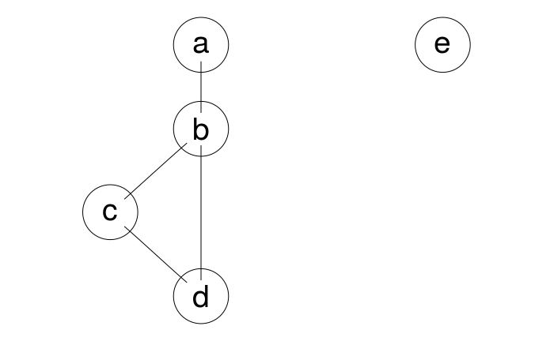

```r
library(Rgraphviz)
plot(ug0)
```

```r
# igraph object
library(igraph)
ug0i = ug(~a:b+b:c:d+e, result = "igraph")
ug0i
```

```
IGRAPH f7f5ef1 UNW- 5 4 --
+ attr: name (v/c), label (v/c), weight (e/n)
+ edges from f7f5ef1 (vertex names):
[1] a--b b--c b--d c--d
```

```
Spring layout was removed, we use Fruchterman-Reingold instead.
```

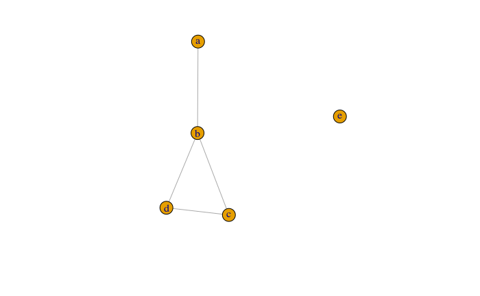

```r
plot(ug0i, layout = layout.spring)
```

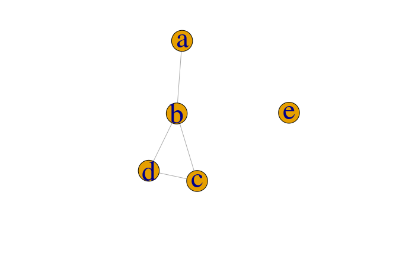

```r
# customed plot function
myiplot = function(x, ...){
  V(x)$size = 30
  V(x)$label.cex = 3
  plot(x, ...)
}
myiplot(ug0i, layout = layout.fruchterman.reingold)
```

```r
ug0a = addEdge("a", "c", ug0)
ug0a = removeEdge("c", "d", ug0)
nodes(ug0)
```

```
[1] "a" "b" "c" "d" "e"
```

```r
edges(ug0)
```

```
[[1]]
A graphNEL graph with undirected edges
Number of Nodes = 5
Number of Edges = 4

attr(,"class")
[1] "igraph.edge"
```

```r
str(edgeList(ug0))
```

```
List of 4
 $ : chr [1:2] "a" "b"
 $ : chr [1:2] "b" "c"
 $ : chr [1:2] "b" "d"
 $ : chr [1:2] "c" "d"
```

A clique is a maximal complete subset. The set of cliques of a graph $\cal G$ is denoted by $\cal C(G)$.

NOTE: In literature the term clique is often used to denoted a complete subset and may not necessarily be maximal.

```r
is.complete(ug0)
```

```
[1] FALSE
```

```r
is.complete(ug0, c("b", "c", "d"))
```

```
[1] TRUE
```

```r
library(RBGL)
maxClique(ug0)
```

```
$maxCliques
$maxCliques[[1]]
[1] "b" "c" "d"

$maxCliques[[2]]
[1] "b" "a"

$maxCliques[[3]]
[1] "e"
```

```r
# or
getCliques(ug0)
```

```
[[1]]
[1] "b" "c" "d"

[[2]]
[1] "b" "a"

[[3]]
[1] "e"
```

path: $\alpha = \alpha_0,\alpha_1,\ldots,\alpha_n=\beta$.

cycle: $\alpha=\beta$.

separate: every path between a vertex in $A\subset V$ and a vertex in $B\subset V$ contains a vertex from $D\subset V$.

```r
separates("a", "d", c("b", "c"), ug0)
```

```
[1] TRUE
```

subgraph:

subgraph induced by $A\subseteq V$:

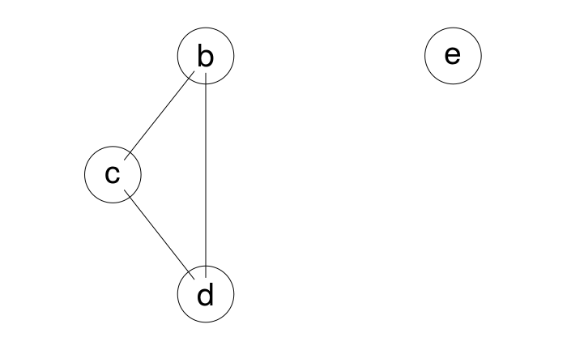

```r
ug1 = subGraph(c("b", "c", "d", "e"), ug0)
plot(ug1)
```

boundary: $\mathrm{bd}(\alpha)=\mathrm{adj}(\alpha)$

neighbours: $\mathrm{ne}(\alpha)$

closure: $\mathrm{cl}(\alpha)=\mathrm{bd}(\alpha)\cup \{\alpha\}$.

```r
adj(ug0, "c")
```

```
$c
[1] "d" "b"
```

```r
closure("c", ug0)
```

```
[1] "c" "d" "b"
```

## Directed Acyclic Graphs

```r
dag0 = dag(~a, ~b*a, ~c*a*b, ~d*c*e, ~e*a, ~g*f)
dag0 = dag(~a+b*a+c*a*b+d*c*e+e*a+g*f)
dag0 = dag(~a+b|a+c|a*b+d|c*e+e|a+g|f)
dag0 = dag("a", c("b", "a"), c("c", "a", "b"), c("d", "c", "e"), c("e", "a"), c("g", "f"))
dag0
```

```
A graphNEL graph with directed edges
Number of Nodes = 7
Number of Edges = 7
```

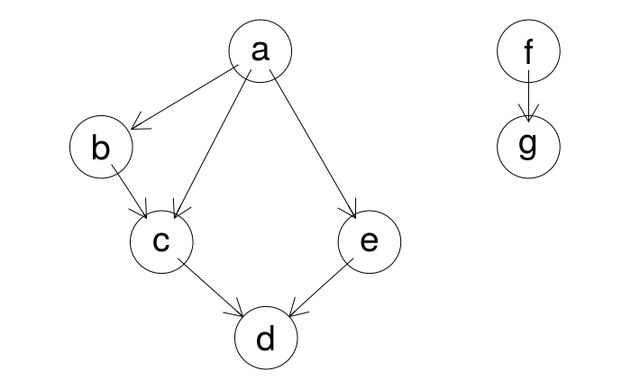

```r
plot(dag0)
```

```r
nodes(dag0)
```

```
[1] "a" "b" "c" "d" "e" "g" "f"
```

```r
str(edges(dag0))
```

[output not shown]

```r
str(edgeList(dag0))
```

```
List of 7
 $ : chr [1:2] "a" "b"
 $ : chr [1:2] "a" "c"
 $ : chr [1:2] "a" "e"
 $ : chr [1:2] "b" "c"
 $ : chr [1:2] "c" "d"
 $ : chr [1:2] "e" "d"
 $ : chr [1:2] "f" "g"
```

```r
vpardag0 = vpar(dag0)
vpardag0$c
```

```
[1] "c" "a" "b"
```

path:

parents:

children:

ancestor:

ancestral set:

ancestral graph:

```r
parents("d", dag0)
```

```
[1] "c" "e"
```

```r
children("c", dag0)
```

```
[1] "d"
```

```r
ancestralSet(c("b", "e"), dag0)
```

```
[1] "a" "b" "e"
```

```r
ancestralGraph(c("b", "e"), dag0)
```

```
A graphNEL graph with directed edges
Number of Nodes = 3
Number of Edges = 2
```

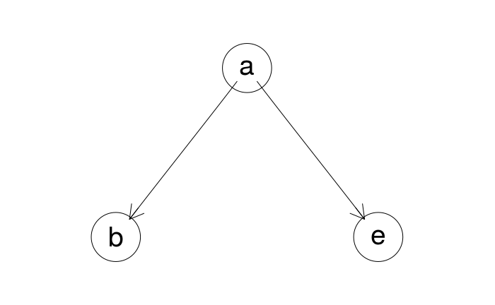

```r
plot(ancestralGraph(c("b", "e"), dag0))
```

moralization:

1. add edges between the parents of each node
2. replace all directed edges with undirected ones

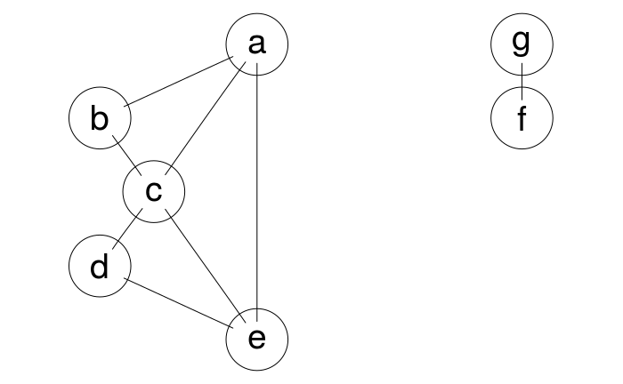

```r
dag0m = moralize(dag0)
plot(dag0m)
```

## Mixed Graphs

path: $v_i-v_{i+1}$, $v_i\leftrightarrow v_{i+1}$ or $v_i\rightarrow v_{i+1}$.

undirected: all are $v_i-v_{i+1}$

directed: all are $v_i\rightarrow v_{i+1}$.

semi-directed (?): at least one $v_i\rightarrow v_{i+1}$.

cycle: $v_i=v_{k+1}$

```r
adjm = matrix(c(0,1,1,0,1,0,0,1,1,0,0,0,1,1,1,0), nrow=4)
rownames(adjm) <- colnames(adjm) <- letters[1:4]
adjm
```

```
  a b c d
a 0 1 1 1
b 1 0 0 1
c 1 0 0 1
d 0 1 0 0
```

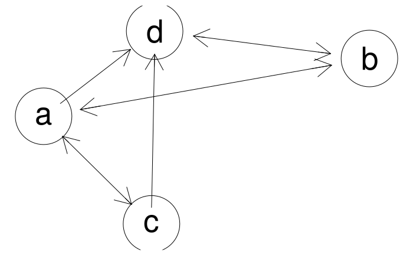

```r
gG = as(adjm, "graphNEL")
plot(gG, "neato")
```

```
Spring layout was removed, we use Fruchterman-Reingold instead.
```

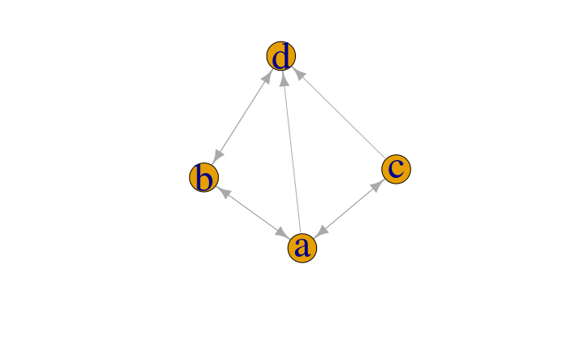

```r
gG1 <- as(adjm, "igraph")
myiplot(gG1, layout = layout.spring)
```

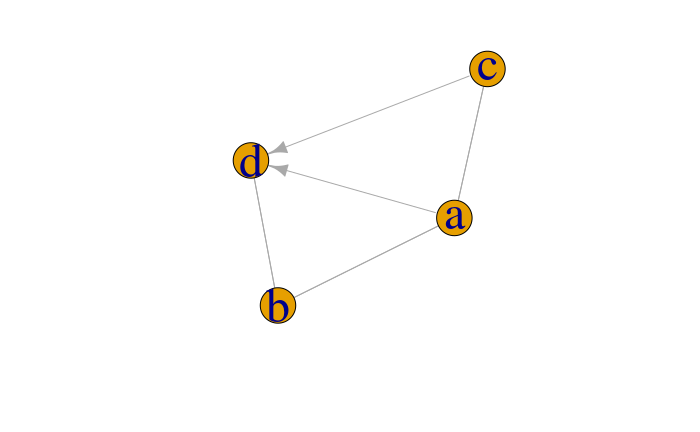

```r
# display undirected instead of bidirected edges
E(gG1)$arrow.mode = c(2, 0)[1+is.mutual(gG1)]
myiplot(gG1, layout = layout.fruchterman.reingold)
```

chain graph: mixed graph with no bidirected edges and no semi-directed cycles

```
Spring layout was removed, we use Fruchterman-Reingold instead.
```

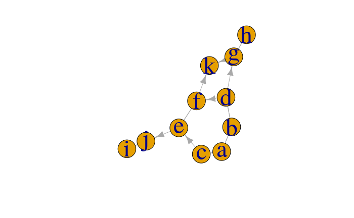

```r
d1 = matrix(0, 11, 11)
d1[1,2] <- d1[2,1] <- d1[1,3] <- d1[3,1] <- d1[2,4] <- d1[4,2] <- d1[5,6] <- d1[6,5] <- 1
d1[9,10] <- d1[10,9] <- d1[7,8] <- d1[8,7] <- d1[3,5] <- d1[5,10] <- d1[4,6] <- d1[4,7] <- 1
d1[6,11] <- d1[7,11] <- 1
rownames(d1) <- colnames(d1) <- letters[1:11]
cG1 <- as(d1, "igraph")
E(cG1)$arrow.mode <- c(2,0)[1+is.mutual(cG1)]
myiplot(cG1, layout=layout.spring)
```

components: the connected components of the graph formed after removing all directed edges from $\cal G$. All edges within a component are undirected, and all edges between components are directed. Also, all arrows between any two components have the same direction.

```r
# lcd package had been removed from CRAN
# the source package is also cannot be installed.
# so I extract the source code as follows (which depends on another package `ggm`)
library(ggm)
`is.chaingraph` <-
function(amat)
{
    wmat <- matrix(as.integer((amat + t(amat)) > 1), nrow = nrow(amat))
    wg <- graph.adjacency(wmat, mode = "undirected")
    cc <- clusters(wg)
    neworder <- order(cc$membership)
    a <- matrix(0, nrow = length(cc$csize), ncol = length(cc$csize))
    b <- cumsum(cc$csize)
    wmat <- amat[neworder, neworder]
    for(i in 1: length(cc$csize)){
        for(j in 1: length(cc$csize)){
            if(j != i){
                a[i,j] <- as.integer(sum(wmat[(max(b[i-1],0)+1):b[i],
                                              (max(b[j-1],0)+1):b[j]]) > 0)
            }
        }
    }
    rownames(a) <- colnames(a) <- as.character(1:length(b))
    output <- isAcyclic(a)
    for(i in 1:length(b)){
        temp <- wmat[(max(b[i-1],0)+1):b[i], (max(b[i-1],0)+1):b[i]]
        if (!all(temp == t(temp))) {
            output <- FALSE
            break
        }
    }
    chainorder <- topOrder(a)
    vertorder<-c()
    chainsize<-c()
    if(output == TRUE){
        for(k in 1:length(b)){
            ## vertorder <- c(vertorder, which(cc$membership == chainorder[k]-1))
            vertorder <- c(vertorder, which(cc$membership == chainorder[k]))
            chainsize <- c(chainsize, cc$csize[chainorder[k]])
        }
    }
    return(list(result = output,
                vert.order = vertorder,
                chain.size = chainsize))
}
is.chaingraph(as(cG1, "matrix"))
```

```
$result
[1] TRUE

$vert.order
 [1]  1  2  3  4  5  6  7  8  9 10 11

$chain.size
[1] 4 2 2 2 1
```

condition independence graph (CIG): or Markov graph

One way to construct the CIG: first draw the complete graph, and then remove those conditional independent pairs.

In $k$ dimensions, there are $2^{\binom{k}{2}}$ different graphs. If it also includes the subgraph, the number of figures would be

$$\sum_{i=0}^k\binom{k}{i}2^{\binom{i}{2}}$$

**The separation theorem**:

Minimal separating subsets:

**local Markov property:** $i\perp \!\!\! \perp rest | boundary$.

**pairwise Markov property:**

**global Markov property:**

directed independence graph

recursive factorisation identity

wermuth condition

moral graph

chain independence graph

**d-separation:** $A$ and $B$ are $d$-separated by a set $C$ iff they are separated in the graph formed by moralizing the anterior graph of $A\cup B\cup C$.

```r
d.separates <- function(a, b, c, dag){
  separates(a, b, c,
            gRbase::moralize(ancestralGraph(union(union(a,b),c),
                                            dag)))
}
d.separates("c", "e", "a", dag0)
```

```
[1] TRUE
```

```r
# alternatively
dSep(as(dag0, "matrix"), "c", "e", "a")
```

```
[1] TRUE
```

c-separation in chain graphs is similar to that of $d$-separation. $A$ and $B$ are $c$-separated by a set $C$ iff they are separated in the graph formed by moralizing the anterior graph of $A\cup B\cup C$.

## More about graphs

A node in an undirected graph is **simplicial** if its boundary is complete.

```r
is.simplicial("b", ug0)
simplicialNodes(ug0)
```

connected components

```r
conComp(ug0)
```

chord:

chordless: no chords

triangulated or chordal: no chordless cycles of length $\ge 4$.

decompose: complete and separates, and union equals to the whole set

```r
is.decomposition("a", "d", c("b", "c"), ug0)
```

```
[1] FALSE
```

decomposable: complete or it can be decomposed into decompsable subgraphs. equivalent to triangulated.

perfect ordering: if $bd(i)\cap \{1,\ldots,i-1\}$ is complete for all $i$. if the graph is triangulated, then a perfect ordering can be obtained with the maximum cardinality search (or mcs) algorithm.

```r
is.decomposition(c("a", "b", "c", "d"), character(0), "e", ug0)
mcs(ug0)
# or control the order
mcs(ug0, root = c("d", "c", "a"))
```

running interaction property (RIP ordering):

```r
rip(ug0)
```

```
cliques
  1 : b a
  2 : b c d
  3 : e
separators
  1 :
  2 : b
  3 :
parents
  1 : 0
  2 : 1
  3 : 0
```

fill-ins

```r
ug2 = ug(~a:b:c+c:d+d:e+a:e)
is.triangulated(ug2)
```

```
[1] FALSE
```

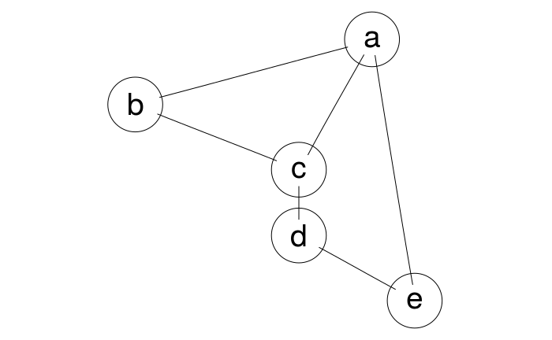

```r
plot(ug2)
```

```r
ug3 = triangulate(ug2)
is.triangulated(ug3)
```

```
[1] TRUE
```

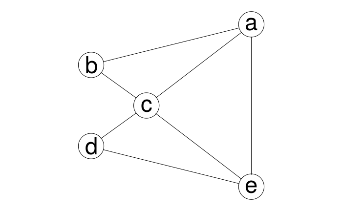

```r
plot(ug3)
```

```r
ug3 = triangulate(ug2)
is.triangulated(ug3)
```

```
[1] TRUE
```

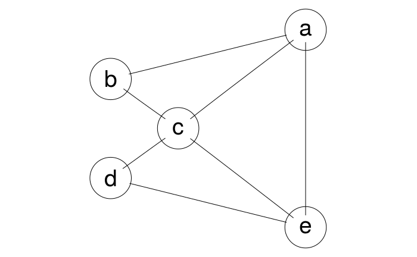

```r
plot(ug3)
```

some of the fill-ins may be superfluous in the sense that they could be removed and still give a triangulated graph. A triangulation with no superfluous fill-ins is called a minimal triangulation.

finding a minimum triangulation is known to be NP-hard.

```r
G1 <- ug(~a:b+b:c+c:d+d:e+e:f+a:f+b:e)
mt1.G1 <- minimalTriang(G1)
G2 <- ug(~a:b:e:f+b:c:d:e)
mt2.G1<-minimalTriang(G1, tobject=G2)
par(mfrow=c(2,2))
plot(G1, sub="G1")
plot(mt1.G1, sub="mt1.G1")
```

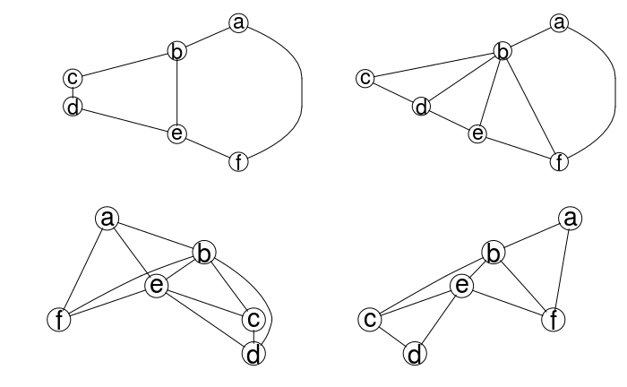

```r
plot(G2, sub="G2")
plot(mt2.G1, sub="mt2.G1")
```

maximal prime subgraph decomposition: the smallest subgraphs into which the graph can be decomposed.

```r
G1 <- ug(~a:b+b:c+c:d+d:e+e:f+a:f+b:e)
G1.rip <- mpd(G1)
G1.rip
```

```
cliques
  1 : b a f e
  2 : b d e c
separators
  1 :
  2 : b e
parents
  1 : 0
  2 : 1
```

```r
par(mfrow=c(1,3))
plot(G1, main="G1")
plot(subGraph(G1.rip$cliques[[1]], G1), main="subgraph 1")
```

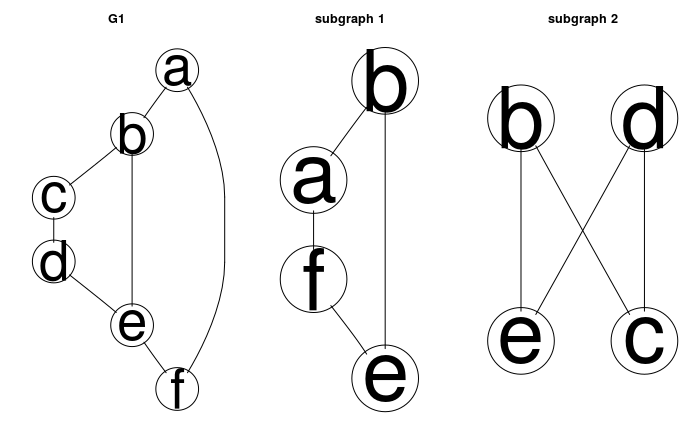

```r
plot(subGraph(G1.rip$cliques[[2]], G1), main="subgraph 2")
```

Markov blanket of a vertex $v$ in a DAG $\cal G$ may be defined as the minimal set that $d$-separates $v$ from the remaining variables. It is easily derived as the set of neighbors to $v$ in the moral graph of $\cal G$.

```r
adj(moralize(dag0), "e")
```

```
$e
[1] "a" "c" "d"
```

## Graph layout in Rgraphviz

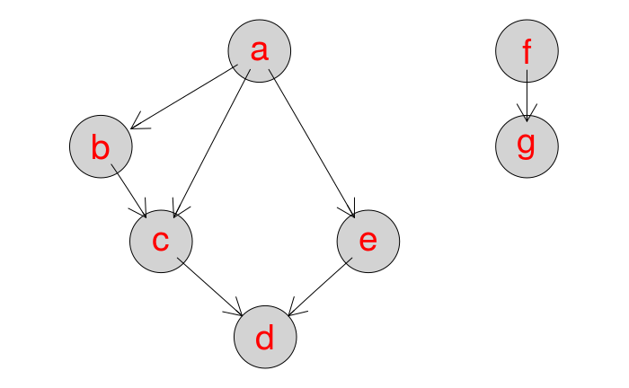

```r
plot(dag0, attrs=list(node = list(fillcolor="lightgrey", fontcolor="red")))
```

```r
edgeNames(ug3)
```

```
[1] "a~b" "a~c" "a~e" "b~c" "c~d" "c~e" "d~e"
```

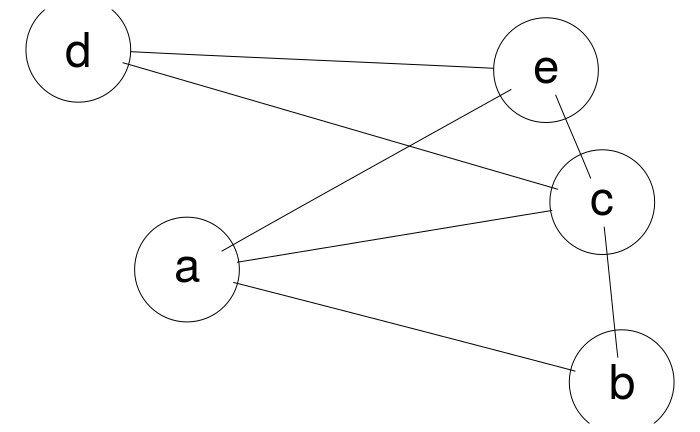

```r
ng3 <- agopen(ug3, name="ug3", layoutType="neato")
ng4 <- ng3
AgEdge(ng4) <- AgEdge(ng4)[-3]
plot(ng3)
```

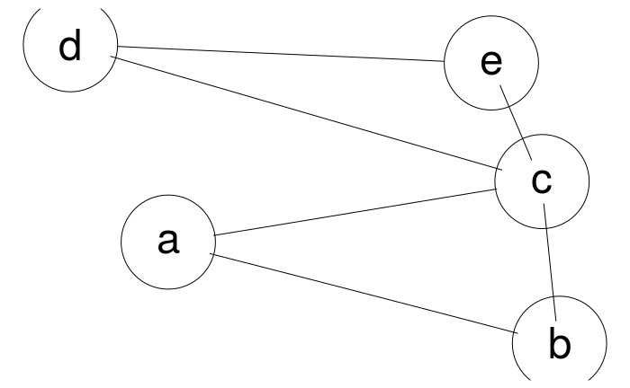

```r
plot(ng4)
```

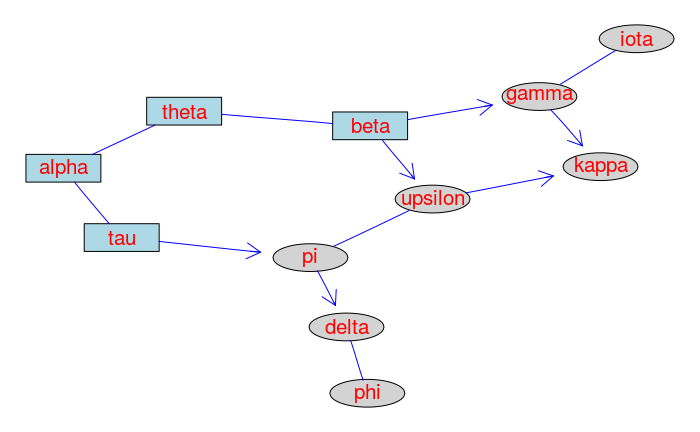

```r
cG1a <- as(cG1, "graphNEL")
nodes(cG1a) <- c("alpha","theta","tau","beta","pi","upsilon","gamma", "iota","phi","delta","kappa")
edges <- buildEdgeList(cG1a)
for (i in 1:length(edges)) {
  if (edges[[i]]@attrs$dir=="both") edges[[i]]@attrs$dir <- "none"
  edges[[i]]@attrs$color <- "blue"
}
nodes <- buildNodeList(cG1a)
for (i in 1:length(nodes)) {
  nodes[[i]]@attrs$fontcolor <- "red"
  nodes[[i]]@attrs$shape <- "ellipse"
  nodes[[i]]@attrs$fillcolor <- "lightgrey"
  if (i <= 4) {
    nodes[[i]]@attrs$fillcolor <- "lightblue"
    nodes[[i]]@attrs$shape <- "box"
  }
}
cG1al <- agopen(cG1a, edges=edges, nodes=nodes, name="cG1a", layoutType="neato")
plot(cG1al)
```

```r
ug4 <- graph.formula(a -- b:c, c -- b:d, e -- a:d)
plot(ug4, layout=layout.graphopt)
```

```r
ug4.2 <- graph.empty(n=5, directed=FALSE)
V(ug4.2)$name <- V(ug4.2)$label <- letters[1:5]
ug4.2 <- add.edges(ug4.2, c(0,1, 0,2, 0,4, 1,2, 2,3, 3,4)+1) # now labelled from 1, not 0
ug4.2
```

```
IGRAPH ffa505d UN-- 5 6 --
+ attr: label (v/c), name (v/c)
+ edges from ffa505d (vertex names):
[1] a--b a--c a--e b--c c--d d--e
```

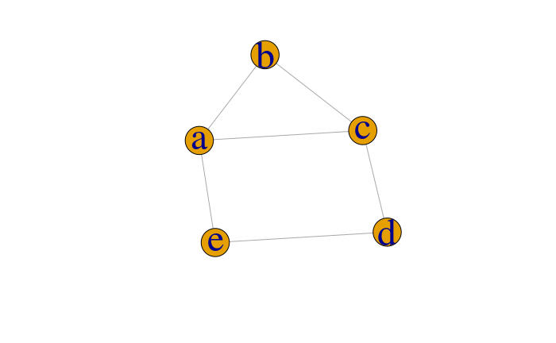

```r
myiplot(ug4, layout=layout.graphopt)
```

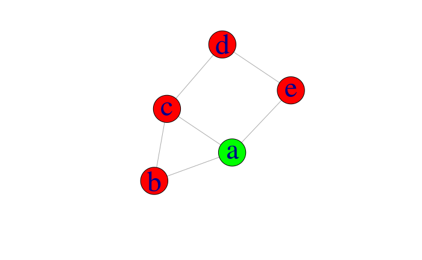

```r
ug4$layout <- layout.graphopt(ug4)
V(ug4)$label <- V(ug4)$name
V(ug4)$color <- "red"
V(ug4)[1]$color <- "green"
V(ug4)$size <- 40
V(ug4)$label.cex <- 3
plot(ug4)
```

```r
ug5 <- set.vertex.attribute(ug4, "discrete", value=c(T,T,F,F,T))
V(ug5)[discrete]$color <- "green"
V(ug5)[!discrete]$color <- "red"
plot(ug5)
```

```r
tkplot(ug4)
xy <- tkplot.getcoords(2)
plot(ug4, layout=xy)
layout.spring(ug4)
```

```r
# same layout
ug5 <- ug(~A*B*C + B*C*D + D*E, result='igraph')
ug6 <- ug(~A*B+B*C+C*D+D*E, result='igraph')
ug6$layout <- ug5$layout <- layout.spring(ug5)
V(ug5)$size <- V(ug6)$size <- 50
V(ug5)$label.cex <- V(ug6)$label.cex <- 3
par(mfrow=c(1,2))
plot(ug5); plot(ug6)
```

```r
em1 <- c(0,0,1,0,1,0,0,1,1,0,0,0,0,1,1,0)
dim(em1) <- c(4,4)
iG <- graph.adjacency(em1)
V(iG)$shape <- c("circle","square","circle","square")
V(iG)$color <- c("red","green")
V(iG)$label <- c("A", "B", "C", "D")
E(iG)$arrow.mode <- c(2,0)[1+is.mutual(iG)]
E(iG)$color <- c("blue", "black")
E(iG)$curved <- c(T,F,F,F,F,F)
iG$layout <- layout.graphopt(iG)
myiplot(iG)
```

```r
library(sna)
aG <- as(graph.famous("Meredith"),"matrix")
gplot3d(aG)
```

```r
# alternative graph representations
V <- c("a","b","c","d")
edL <- vector("list", length=4)
names(edL) <- V
for (i in 1:4) {
  edL[[i]] <- list(edges=5-i)
}
gR <- new("graphNEL", nodes=V, edgeL=edL)
plot(gR)
```

```r
ug_NEL <- ug(~a:b+b:c:d+e)
ug_igraph <- as(ug_NEL, "igraph")
separates("a","d",c("b","c"), ug_NEL)
```

```
[1] TRUE
```

```r
# equivalent to
querygraph(ug_igraph, 'separates', "a","d",c("b","c"))
```

```
[1] TRUE
```